# Lecture 9 - Machine Learning

# Machine Learning

機器學習是實現人工智慧的其中一種方式。是通過演算法來分析數據、從中學習，以及判斷或預測現實世界裡的某些事，使用大量的數據、 過去經驗和演算法來「訓練」**機器**，讓它**學習**到一定程度後，就可以去預測及執行任務。

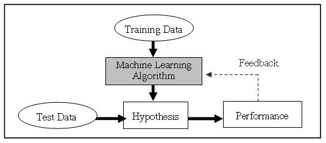

- 非監督式學習（Unsupervised Learning）
- 半監督學習（Semi-supervised learning）
- 監督式學習（Supervised Learning）
- 增強學習 (Reinforcement learning)

**名詞介紹**：

特徵/Features/Attributes/Variables

類別/Labels/Classes

分類classification

分群clustering

# 非監督式學習

集群分析：e.g.同溫層、小圈圈。同群體相似度高（群內變異小、群間變異大）

1. 計算個體間相似程度/距離(similarity/dissimilarity) ＊Note: Distance = 1-Similarity
   - 歐氏距離Euclidean distance
   - 漢明距離Hamming distance：(幾個不同) e.g. 1011101與1001001之間的漢明距離是2。
   - 夾角餘弦Cosine similarity：$cos(\theta)=\frac{X\cdot Y}{||X||\cdot ||Y||}$
   - 相關係數Correlation coefficient
2. 決定分群方法及群數
   - K-means、階層式分群
3. 描述各群體特徵及關係

### K-means

分割式分群(Partitional Clustering)：需事先指定分群數目k，經過不斷的迭代，直到群內的變異最小。

Clusters data into k groups of equal variance by minimizing the **within-cluster sum of squares** ($\sum_{k=1}^K W(C_k)=\sum_{k=1}^K\sum_{x_i\in C_k}(x_i-\mu_k)^2$). Divide n data points into k disjoint clusters, each described by its mean.

1. Choose k (random) data points (seeds) to be the initial centroids, cluster centers
2. Assign each data point to the closest centroid
3. Re-compute the centroids using the current cluster memberships
4. If a convergence criterion is not met, repeat steps 2 and 3

https://uc-r.github.io/kmeans_clustering

```
kmeans(x,k)
```

### Hierarchical

階層式分群(Hierarchical Clustering)：不需指定分群數目，讓資料自動由上往下/由下往上結合起來。

Distance:

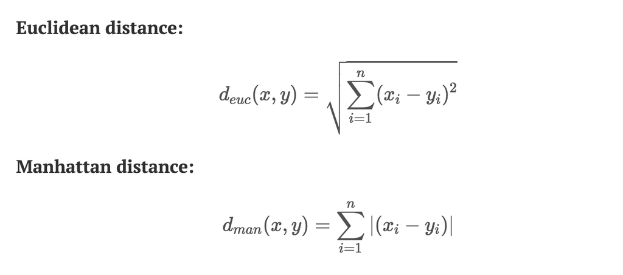

Method:

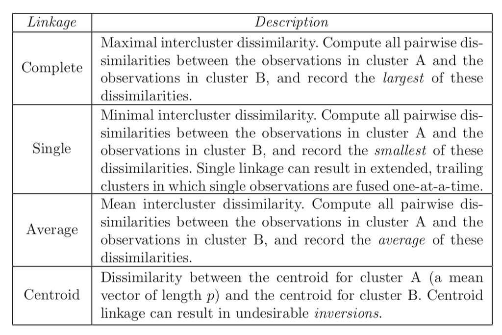

```
hclust(distance,method)
```

http://www.sthda.com/english/wiki/beautiful-dendrogram-visualizations-in-r-5-must-known-methods-unsupervised-machine-learning

https://rpubs.com/gaston/dendrograms

# Exercise

read.csv(“Mall_Customers.csv”,sep=“,”)

1. 對變數做以下轉換

當尺度單位不一致時，有數值變數也有類別變數，可對所有變數做標準化：

- 類別變數：轉換為1和0
- 數值變數：轉換至「以最大最小值為1和0的尺度中」，(x-min)/range
2. 決定分群方法和群數
3. 對群做EDA描述

https://www.kaggle.com/vjchoudhary7/customer-segmentation-tutorial-in-python/version/1?#_=_